# LME Analysis of NUCs

Antoin Rodgers

18.05.2022

## L targets

### Analysis of L timing

- initial run, step() found: `l_t ~ pre_syls + gender + (1 | speaker) + (1 | str_syl)`
- intercepts only model, needs trimming: rfemoved residual sd > 3

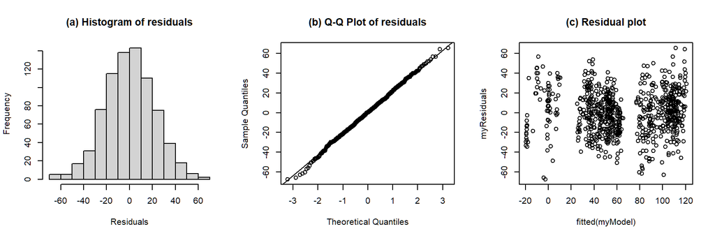

```
## Formula:  l_t ~ foot_syls + pre_syls + fin_phon + nuc_new_word + gender + (1 | speaker) + (1 | str_syl) + (1 | foot_dur)
##
## Linear mixed model fit by REML. t-tests use Satterthwaite's method [
## lmerModLmerTest]
## Formula: l_t_equation
##    Data: nuc_l_t_data.trimmed
## Control:
## lmerControl(optimizer = optimizer, calc.derivs = FALSE, optCtrl = list(method = "nlminb",
##     starttests = FALSE, kkt = FALSE))
##
## REML criterion at convergence: 7075.8
##
## Scaled residuals:
##     Min      1Q  Median      3Q     Max
## -3.0190 -0.6610  0.0139  0.6161  2.9342
##
## Random effects:
##  Groups   Name        Variance Std.Dev.
##  foot_dur (Intercept)  17.9     4.231
##  speaker  (Intercept) 132.3    11.503
##  str_syl  (Intercept) 531.9    23.062
##  Residual             499.9    22.358
## Number of obs: 780, groups:  foot_dur, 316; speaker, 11; str_syl, 3
##
## Fixed effects:
##                  Estimate Std. Error       df t value Pr(>|t|)
## (Intercept)       92.4435    15.1414   3.2339   6.105  0.00708 **
## foot_syls2        -0.4817     4.2390 758.1258  -0.114  0.90956
## foot_syls3         0.9925     3.3250 735.5375   0.299  0.76541
## foot_syls4        -1.8040     5.3157 756.7648  -0.339  0.73443
## pre_syls1         -4.8688     3.3479 759.6802  -1.454  0.14628
## pre_syls2         -1.5015     5.3100 758.9128  -0.283  0.77743
## pre_syls3        -11.8707     5.4851 761.2102  -2.164  0.03076 *
## fin_phonL%         3.9292     5.1199 766.7528   0.767  0.44306
## nuc_new_wordTRUE  -3.5169     3.2347 752.3251  -1.087  0.27728
## genderM          -54.9668     7.1569   8.9526  -7.680 3.15e-05 ***
## ---
## Signif. codes:  0 '***' 0.001 '**' 0.01 '*' 0.05 '.' 0.1 ' ' 1
##
## Correlation of Fixed Effects:
```

[output cut: 24 more lines]

```
## Degrees of freedom method: Satterthwaite
##
##              Eliminated  Sum Sq Mean Sq NumDF  DenDF F value    Pr(>F)
## foot_syls             1   128.3    42.8     3 760.15  0.0826  0.969491
## fin_phon              2   243.2   243.2     1 770.00  0.4717  0.492421
## nuc_new_word          3   592.0   592.0     1 765.23  1.1485  0.284207
## pre_syls              0  7081.5  2360.5     3 761.67  4.5791  0.003465 **
## gender                0 31001.3 31001.3     1   8.99 60.1388 2.857e-05 ***
## ---
## Signif. codes:  0 '***' 0.001 '**' 0.01 '*' 0.05 '.' 0.1 ' ' 1
##
## Model found:
## l_t ~ pre_syls + gender + (1 | speaker) + (1 | str_syl)
##
## isSingular(my_model, tol = 1e-05 ) --> FALSE
```

Anova of model: l_t ~ foot_syls + pre_syls + fin_phon + nuc_new_word + gender + (1 | speaker) + (1 | str_syl) + (1 | foot_dur)

| term | sumsq | meansq | NumDF | DenDF | F value | p.value | signif. |
| --- | --- | --- | --- | --- | --- | --- | --- |
| foot_syls | 143.797 | 47.932 | 3 | 754.364 | 0.096 | 9.623048e-01 |  |
| pre_syls | 6234.373 | 2078.124 | 3 | 753.499 | 4.157 | 6.193616e-03 | p<0.01 |
| fin_phon | 294.400 | 294.400 | 1 | 766.753 | 0.589 | 4.430572e-01 |  |
| nuc_new_word | 590.885 | 590.885 | 1 | 752.325 | 1.182 | 2.772783e-01 |  |
| gender | 29484.675 | 29484.675 | 1 | 8.953 | 58.985 | 3.153727e-05 | p<0.001 |

[[1]]

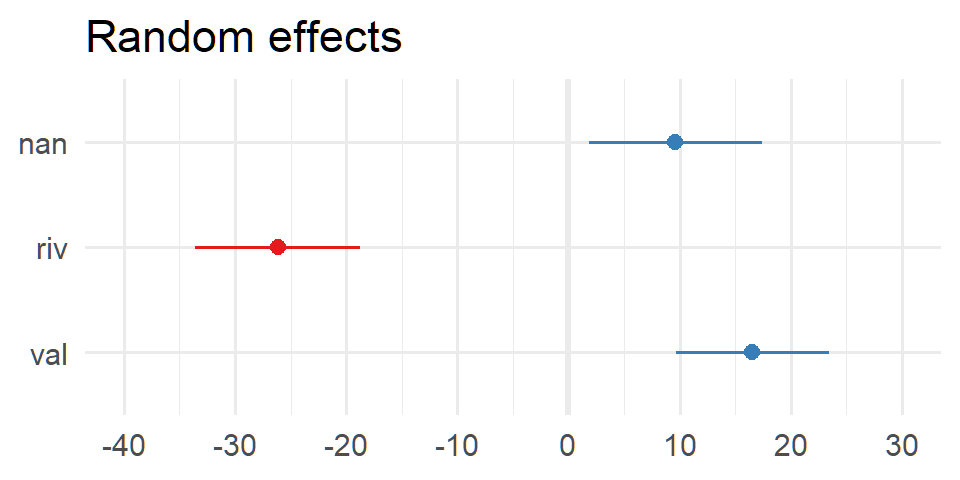

Conditional and marginal R<sup>2</sup> of model

| R2_conditional | R2_marginal |
| --- | --- |
| 0.74 | 0.39 |

$foot_syls

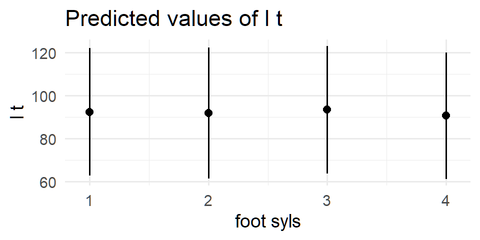

$pre_syls

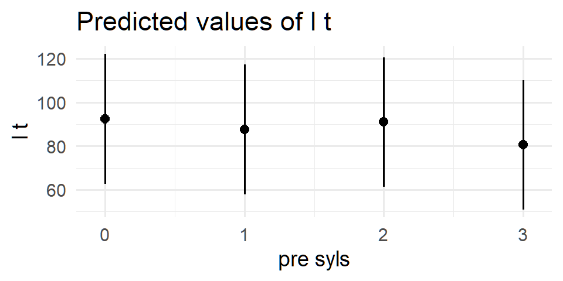

$fin_phon

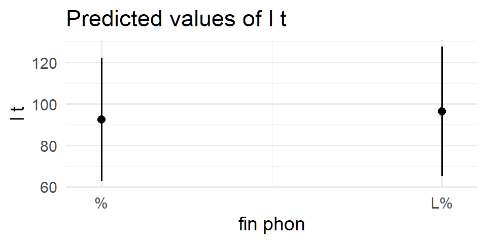

$nuc_new_word

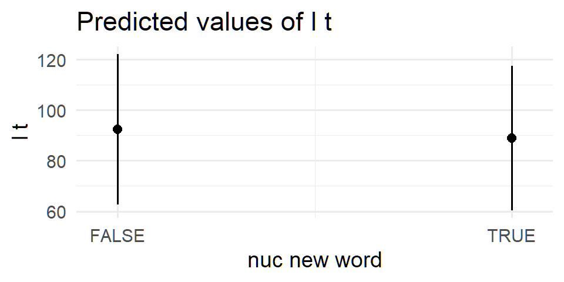

$gender

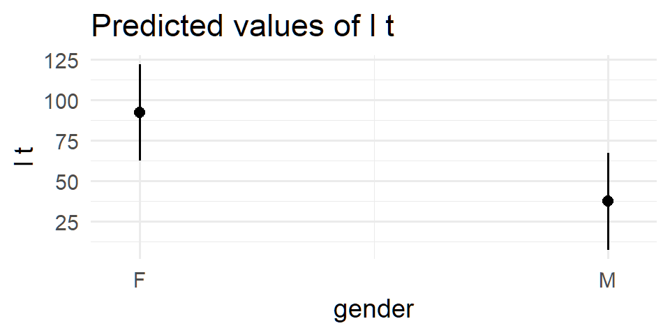

summary of model: l_t ~ foot_syls + pre_syls + fin_phon + nuc_new_word + gender + (1 | speaker) + (1 | str_syl) + (1 | foot_dur)

| term | estimate | conf.low | conf.high | std.error | t.value | df | p.value |
| --- | --- | --- | --- | --- | --- | --- | --- |
| (Intercept) | 92.444 | 46.169796 | 138.717235 | 15.141 | 6.105 | 3.23 | 0.0071 |
| foot_syls2 | -0.482 | -8.803207 | 7.839839 | 4.239 | -0.114 | 758.13 | 0.9096 |
| foot_syls3 | 0.993 | -5.535064 | 7.520080 | 3.325 | 0.299 | 735.54 | 0.7654 |
| foot_syls4 | -1.804 | -12.239213 | 8.631265 | 5.316 | -0.339 | 756.76 | 0.7344 |
| pre_syls1 | -4.869 | -11.440964 | 1.703436 | 3.348 | -1.454 | 759.68 | 0.1463 |
| pre_syls2 | -1.502 | -11.925658 | 8.922586 | 5.310 | -0.283 | 758.91 | 0.7774 |
| pre_syls3 | -11.871 | -22.638473 | -1.102879 | 5.485 | -2.164 | 761.21 | 0.0308 |
| fin_phonL% | 3.929 | -6.121420 | 13.979761 | 5.120 | 0.767 | 766.75 | 0.4431 |
| nuc_new_wordTRUE | -3.517 | -9.866963 | 2.833197 | 3.235 | -1.087 | 752.33 | 0.2773 |
| genderM | -54.967 | -71.169985 | -38.763545 | 7.157 | -7.680 | 8.95 | 3.2e-05 |

b0 for l_t ~ foot_syls + pre_syls + fin_phon + nuc_new_word + gender + (1 | speaker) + (1 | str_syl) + (1 | foot_dur)

| intercept | estimate | conf.low | conf.high | std.error | t.value | df | p.value |
| --- | --- | --- | --- | --- | --- | --- | --- |
| foot_syls1 | 93.6 | 46.5 | 140.7 | 15.607 | 6.000 | 3.32 | 0.007 |
| foot_syls2 | 95.7 | 49.7 | 141.6 | 16.067 | 5.954 | 3.72 | 0.005 |
| foot_syls3 | 96.6 | 49.4 | 143.7 | 15.603 | 6.189 | 3.31 | 0.006 |
| foot_syls4 | 94.2 | 46.6 | 141.9 | 15.431 | 6.107 | 3.17 | 0.007 |
| pre_syls0 | 93.6 | 46.5 | 140.7 | 15.607 | 6.000 | 3.32 | 0.007 |
| pre_syls1 | 85.9 | 38.8 | 132.9 | 15.614 | 5.499 | 3.32 | 0.009 |
| pre_syls2 | 87.6 | 40.5 | 134.7 | 15.596 | 5.619 | 3.31 | 0.009 |
| pre_syls3 | 80.1 | 32.9 | 127.4 | 15.544 | 5.156 | 3.27 | 0.011 |

b1 for l_t ~ foot_syls + pre_syls + fin_phon + nuc_new_word + gender + (1 | speaker) + (1 | str_syl) + (1 | foot_dur)

| intercept | slope | estimate | conf.low | conf.high | std.error | t.value | df | p.value |
| --- | --- | --- | --- | --- | --- | --- | --- | --- |
| foot_syls1 | foot_syls2 | 2.029 | -6.622 | 10.7 | 4.407 | 0.460 | 760.08 | 0.645 |
| foot_syls1 | foot_syls3 | 2.926 | -3.919 | 9.772 | 3.487 | 0.839 | 737.40 | 0.402 |
| foot_syls1 | foot_syls4 | 0.595 | -10.3 | 11.5 | 5.553 | 0.107 | 763.56 | 0.915 |
| foot_syls2 | foot_syls3 | 0.897 | -8.293 | 10.1 | 4.681 | 0.192 | 762.13 | 0.848 |
| foot_syls2 | foot_syls4 | -1.435 | -12.7 | 9.795 | 5.721 | -0.251 | 764.61 | 0.802 |
| foot_syls3 | foot_syls4 | -2.332 | -13.6 | 8.964 | 5.754 | -0.405 | 764.73 | 0.685 |
| pre_syls0 | pre_syls1 | -7.774 | -14.7 | -0.896 | 3.504 | -2.219 | 766.13 | 0.027 |
| pre_syls0 | pre_syls2 | -6.008 | -16.9 | 4.905 | 5.559 | -1.081 | 768.94 | 0.28 |
| pre_syls0 | pre_syls3 | -13.5 | -24.8 | -2.189 | 5.756 | -2.343 | 768.88 | 0.019 |
| pre_syls1 | pre_syls2 | 1.766 | -6.699 | 10.2 | 4.312 | 0.410 | 767.01 | 0.682 |
| pre_syls1 | pre_syls3 | -5.715 | -14.7 | 3.227 | 4.555 | -1.255 | 764.10 | 0.21 |
| pre_syls2 | pre_syls3 | -7.481 | -14.1 | -0.841 | 3.382 | -2.212 | 751.23 | 0.027 |
| intercept | fin_phonL% | 3.798 | -6.824 | 14.4 | 5.411 | 0.702 | 773.59 | 0.483 |
| intercept | nuc_new_wordTRUE | -5 | -11.7 | 1.663 | 3.394 | -1.473 | 766.96 | 0.141 |
| intercept | genderM | -54.2 | -71.4 | -36.9 | 7.603 | -7.122 | 8.96 | 5.6e-05 |

### Analysis of L F0

- Only intercepts only model avoided convergence and singularity issues
- step() suggests: `l_f0 ~ foot_syls + gender + (1 | speaker) + (1 | nuc_pre_text)`
- but random intercepts only model words
- removed speech_rate and str_syl random effects to eliminate singularity in getModelFixedFX()
- model needs trimming (sd residuals > 3)

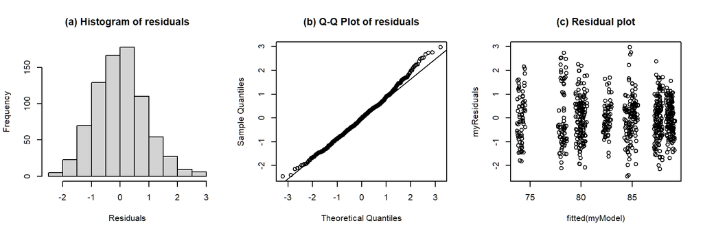

```
## Formula:  l_f0 ~ foot_syls + pre_syls + fin_phon + nuc_new_word + (1 | speaker) + (1 | foot_dur) + (1 | nuc_pre_text)
##
## Linear mixed model fit by REML. t-tests use Satterthwaite's method [
## lmerModLmerTest]
## Formula: l_f0_equation
##    Data: nuc_l_f0.trimmed
## Control:
## lmerControl(optimizer = optimizer, calc.derivs = FALSE, optCtrl = list(method = "nlminb",
##     starttests = FALSE, kkt = FALSE))
##
## REML criterion at convergence: 2179.3
##
## Scaled residuals:
##     Min      1Q  Median      3Q     Max
## -2.6735 -0.6612 -0.0219  0.5735  3.2471
##
## Random effects:
##  Groups       Name        Variance Std.Dev.
##  foot_dur     (Intercept)  0.01673 0.1293
##  nuc_pre_text (Intercept)  0.02513 0.1585
##  speaker      (Intercept) 23.22170 4.8189
##  Residual                  0.83612 0.9144
## Number of obs: 778, groups:  foot_dur, 316; nuc_pre_text, 12; speaker, 11
##
## Fixed effects:
##                   Estimate Std. Error        df t value Pr(>|t|)
## (Intercept)       82.76201    1.47499  10.59027  56.110 1.89e-14 ***
## foot_syls2         0.51402    0.28224   5.38695   1.821 0.123999
## foot_syls3         0.47320    0.13460 726.43129   3.516 0.000466 ***
## foot_syls4         0.88127    0.32596   5.38429   2.704 0.039480 *
## pre_syls1          0.12624    0.26194   3.99640   0.482 0.655067
## pre_syls2         -0.14363    0.34839   4.61543  -0.412 0.698585
## pre_syls3         -0.14176    0.34832   4.59570  -0.407 0.702281
## fin_phonL%        -0.02217    0.20966 758.61576  -0.106 0.915830
## nuc_new_wordTRUE   0.24528    0.16419   5.51830   1.494 0.190040
## ---
## Signif. codes:  0 '***' 0.001 '**' 0.01 '*' 0.05 '.' 0.1 ' ' 1
##
## Correlation of Fixed Effects:
##             (Intr) ft_sy2 ft_sy3 ft_sy4 pr_sy1 pr_sy2 pr_sy3 fn_pL%
```

[output cut: 21 more lines]

```
## Backward reduced fixed-effect table:
## Degrees of freedom method: Satterthwaite
##
##              Eliminated  Sum Sq Mean Sq NumDF  DenDF F value  Pr(>F)
## fin_phon              1  0.0173  0.0173     1 759.11  0.0203 0.88682
## pre_syls              2  1.4632  0.4877     3   4.91  0.5728 0.65753
## nuc_new_word          3  3.1494  3.1494     1   8.55  3.6976 0.08837 .
## foot_syls             0 13.4482  4.4827     3  12.06  5.2637 0.01496 *
## ---
## Signif. codes:  0 '***' 0.001 '**' 0.01 '*' 0.05 '.' 0.1 ' ' 1
##
## Model found:
## l_f0 ~ foot_syls + (1 | speaker) + (1 | nuc_pre_text)
##
## isSingular(my_model, tol = 1e-05 ) --> FALSE
```

Anova of model: l_f0 ~ foot_syls + pre_syls + fin_phon + nuc_new_word + (1 | speaker) + (1 | foot_dur) + (1 | nuc_pre_text)

| term | sumsq | meansq | NumDF | DenDF | F value | p.value | signif. |
| --- | --- | --- | --- | --- | --- | --- | --- |
| foot_syls | 14.213 | 4.738 | 3 | 7.330 | 5.666 | 0.02551979 | p<0.05 |
| pre_syls | 1.465 | 0.488 | 3 | 4.897 | 0.584 | 0.65148169 |  |
| fin_phon | 0.009 | 0.009 | 1 | 758.616 | 0.011 | 0.91582954 |  |
| nuc_new_word | 1.866 | 1.866 | 1 | 5.518 | 2.232 | 0.19004025 |  |

Conditional and marginal R<sup>2</sup> of model

| R2_conditional | R2_marginal |
| --- | --- |
| 0.97 | 0 |

$foot_syls

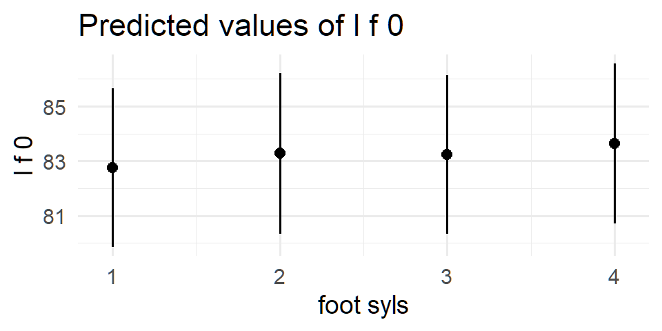

$pre_syls

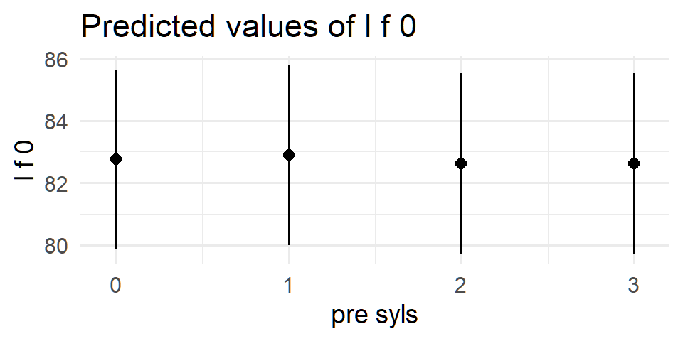

$fin_phon

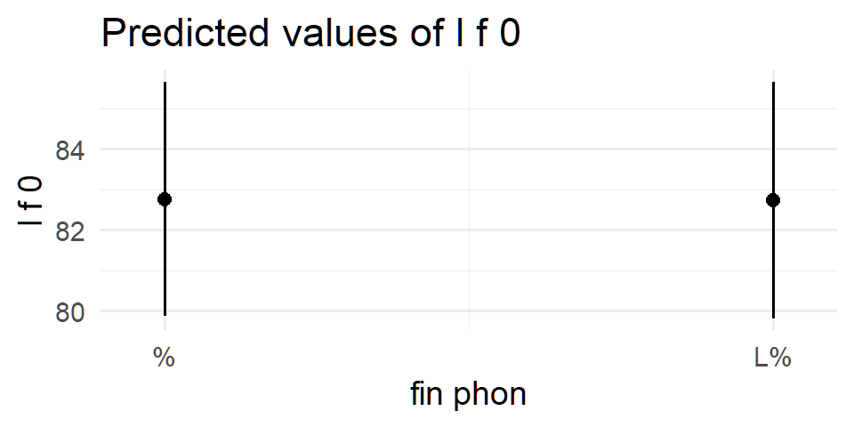

$nuc_new_word

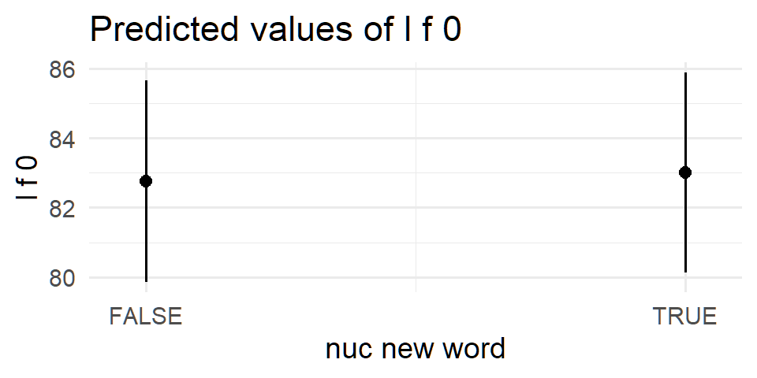

summary of model: l_f0 ~ foot_syls + pre_syls + fin_phon + nuc_new_word + (1 | speaker) + (1 | foot_dur) + (1 | nuc_pre_text)

| term | estimate | conf.low | conf.high | std.error | t.value | df | p.value |
| --- | --- | --- | --- | --- | --- | --- | --- |
| (Intercept) | 82.762 | 79.50018516 | 86.0238438 | 1.475 | 56.110 | 10.59 | 1.9e-14 |
| foot_syls2 | 0.514 | -0.19609289 | 1.2241281 | 0.282 | 1.821 | 5.39 | 0.124 |
| foot_syls3 | 0.473 | 0.20895713 | 0.7374519 | 0.135 | 3.516 | 726.43 | 5e-04 |
| foot_syls4 | 0.881 | 0.06103762 | 1.7014968 | 0.326 | 2.704 | 5.38 | 0.0395 |
| pre_syls1 | 0.126 | -0.60129669 | 0.8537680 | 0.262 | 0.482 | 4.00 | 0.6551 |
| pre_syls2 | -0.144 | -1.06211019 | 0.7748494 | 0.348 | -0.412 | 4.62 | 0.6986 |
| pre_syls3 | -0.142 | -1.06137017 | 0.7778534 | 0.348 | -0.407 | 4.60 | 0.7023 |
| fin_phonL% | -0.022 | -0.43375517 | 0.3894225 | 0.210 | -0.106 | 758.62 | 0.9158 |
| nuc_new_wordTRUE | 0.245 | -0.16513668 | 0.6557026 | 0.164 | 1.494 | 5.52 | 0.19 |

b0 for l_f0 ~ foot_syls + pre_syls + fin_phon + nuc_new_word + (1 | speaker) + (1 | foot_dur) + (1 | nuc_pre_text)

| intercept | estimate | conf.low | conf.high | std.error | t.value | df | p.value |
| --- | --- | --- | --- | --- | --- | --- | --- |
| foot_syls1 | 82.8 | 79.5 | 86 | 1.475 | 56.110 | 10.59 | 1.9e-14 |
| foot_syls2 | 83.3 | 80 | 86.6 | 1.499 | 55.545 | 11.23 | 4.7e-15 |
| foot_syls3 | 83.2 | 80 | 86.5 | 1.475 | 56.433 | 10.59 | 1.8e-14 |
| foot_syls4 | 83.6 | 80.4 | 86.9 | 1.490 | 56.132 | 10.99 | 7.3e-15 |
| pre_syls0 | 82.8 | 79.5 | 86 | 1.475 | 56.110 | 10.59 | 1.9e-14 |
| pre_syls1 | 82.9 | 79.6 | 86.2 | 1.475 | 56.182 | 10.60 | 1.8e-14 |
| pre_syls2 | 82.6 | 79.3 | 85.9 | 1.489 | 55.501 | 10.96 | 8.9e-15 |
| pre_syls3 | 82.6 | 79.3 | 85.9 | 1.489 | 55.500 | 10.96 | 8.8e-15 |

b1 for l_f0 ~ foot_syls + pre_syls + fin_phon + nuc_new_word + (1 | speaker) + (1 | foot_dur) + (1 | nuc_pre_text)

| intercept | slope | estimate | conf.low | conf.high | std.error | t.value | df | p.value |
| --- | --- | --- | --- | --- | --- | --- | --- | --- |
| foot_syls1 | foot_syls2 | 0.514 | -0.196 | 1.224 | 0.282 | 1.821 | 5.39 | 0.124 |
| foot_syls1 | foot_syls3 | 0.473 | 0.209 | 0.737 | 0.135 | 3.516 | 726.43 | 4.7e-04 |
| foot_syls1 | foot_syls4 | 0.881 | 0.061 | 1.701 | 0.326 | 2.704 | 5.38 | 0.039 |
| foot_syls2 | foot_syls3 | -0.041 | -0.75 | 0.669 | 0.288 | -0.142 | 5.85 | 0.892 |
| foot_syls2 | foot_syls4 | 0.367 | -0.452 | 1.187 | 0.330 | 1.113 | 5.66 | 0.311 |
| foot_syls3 | foot_syls4 | 0.408 | -0.412 | 1.228 | 0.330 | 1.235 | 5.68 | 0.265 |
| pre_syls0 | pre_syls1 | 0.126 | -0.601 | 0.854 | 0.262 | 0.482 | 4.00 | 0.655 |
| pre_syls0 | pre_syls2 | -0.144 | -1.062 | 0.775 | 0.348 | -0.412 | 4.62 | 0.699 |
| pre_syls0 | pre_syls3 | -0.142 | -1.061 | 0.778 | 0.348 | -0.407 | 4.60 | 0.702 |
| pre_syls1 | pre_syls2 | -0.27 | -0.84 | 0.3 | 0.230 | -1.175 | 5.66 | 0.287 |
| pre_syls1 | pre_syls3 | -0.268 | -0.84 | 0.304 | 0.229 | -1.169 | 5.57 | 0.29 |
| pre_syls2 | pre_syls3 | 0.002 | -0.355 | 0.358 | 0.142 | 0.013 | 5.44 | 0.99 |
| intercept | fin_phonL% | -0.022 | -0.434 | 0.389 | 0.210 | -0.106 | 758.62 | 0.916 |
| intercept | nuc_new_wordTRUE | 0.245 | -0.165 | 0.656 | 0.164 | 1.494 | 5.52 | 0.19 |

## H targets

### Analysis of H timing

- Only intercepts only model avoided convergence and singularity issues
- step() suggests: `h_t ~ foot_syls + pre_syls + fin_phon + nuc_new_word + gender + (1 | speaker) + (1 | str_syl)`
- Removing speech_rate, foot_dur, and nuc_pre_text random intercepts
- model needs trimming (residual sd > 3.5)

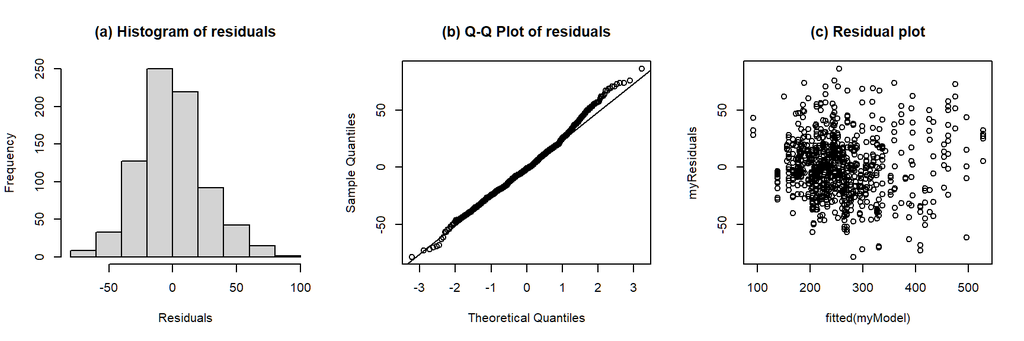

```
## Formula:  h_t ~ foot_syls + pre_syls + fin_phon + nuc_new_word + gender + (1 | speaker) + (1 | str_syl)
##
## Linear mixed model fit by REML. t-tests use Satterthwaite's method [
## lmerModLmerTest]
## Formula: h_t_equation
##    Data: nuc_h_t_data.trimmed
## Control:
## lmerControl(optimizer = optimizer, calc.derivs = FALSE, optCtrl = list(method = "nlminb",
##     starttests = FALSE, kkt = FALSE))
##
## REML criterion at convergence: 7383
##
## Scaled residuals:
##     Min      1Q  Median      3Q     Max
## -2.9652 -0.6816 -0.0549  0.5891  3.2625
##
## Random effects:
##  Groups   Name        Variance Std.Dev.
##  speaker  (Intercept) 586.9    24.23
##  str_syl  (Intercept) 711.9    26.68
##  Residual             697.6    26.41
## Number of obs: 787, groups:  speaker, 11; str_syl, 3
##
## Fixed effects:
##                  Estimate Std. Error      df t value Pr(>|t|)
## (Intercept)       293.154     19.362   4.642  15.141 3.96e-05 ***
## foot_syls2         21.253      4.839 766.112   4.392 1.28e-05 ***
## foot_syls3         95.924      3.835 766.107  25.014  < 2e-16 ***
## foot_syls4        217.839      6.098 767.725  35.723  < 2e-16 ***
## pre_syls1         -33.504      3.855 766.253  -8.692  < 2e-16 ***
## pre_syls2         -38.186      6.110 767.949  -6.249 6.84e-10 ***
## pre_syls3         -44.233      6.326 768.201  -6.992 5.90e-12 ***
## fin_phonL%        -45.707      5.957 769.446  -7.672 5.11e-14 ***
## nuc_new_wordTRUE  -13.416      3.730 767.494  -3.597 0.000342 ***
## genderM           -64.510     14.792   9.006  -4.361 0.001818 **
## ---
## Signif. codes:  0 '***' 0.001 '**' 0.01 '*' 0.05 '.' 0.1 ' ' 1
##
## Correlation of Fixed Effects:
##             (Intr) ft_sy2 ft_sy3 ft_sy4 pr_sy1 pr_sy2 pr_sy3 fn_pL% n__TRU
```

[output cut: 22 more lines]

```
## Degrees of freedom method: Satterthwaite
##
##              Eliminated  Sum Sq Mean Sq NumDF  DenDF F value    Pr(>F)
## foot_syls             0 1207297  402432     3 766.87 576.878 < 2.2e-16 ***
## pre_syls              0   56226   18742     3 764.83  26.866 < 2.2e-16 ***
## fin_phon              0   41065   41065     1 769.45  58.866 5.112e-14 ***
## nuc_new_word          0    9026    9026     1 767.49  12.939 0.0003425 ***
## gender                0   13268   13268     1   9.01  19.019 0.0018178 **
## ---
## Signif. codes:  0 '***' 0.001 '**' 0.01 '*' 0.05 '.' 0.1 ' ' 1
##
## Model found:
## h_t ~ foot_syls + pre_syls + fin_phon + nuc_new_word + gender + (1 | speaker) + (1 | str_syl)
##
## isSingular(my_model, tol = 1e-05 ) --> FALSE
```

Anova of model: h_t ~ foot_syls + pre_syls + fin_phon + nuc_new_word + gender + (1 | speaker) + (1 | str_syl)

| term | sumsq | meansq | NumDF | DenDF | F value | p.value | signif. |
| --- | --- | --- | --- | --- | --- | --- | --- |
| foot_syls | 1207296.868 | 402432.289 | 3 | 766.872 | 576.878 | 4.422576e-196 | p<0.001 |
| pre_syls | 56225.902 | 18741.967 | 3 | 764.834 | 26.866 | 1.582703e-16 | p<0.001 |
| fin_phon | 41065.179 | 41065.179 | 1 | 769.446 | 58.866 | 5.111873e-14 | p<0.001 |
| nuc_new_word | 9025.994 | 9025.994 | 1 | 767.494 | 12.939 | 3.424998e-04 | p<0.001 |
| gender | 13267.988 | 13267.988 | 1 | 9.006 | 19.019 | 1.817793e-03 | p<0.01 |

Conditional and marginal R<sup>2</sup> of model

| R2_conditional | R2_marginal |
| --- | --- |
| 0.9 | 0.7 |

$foot_syls

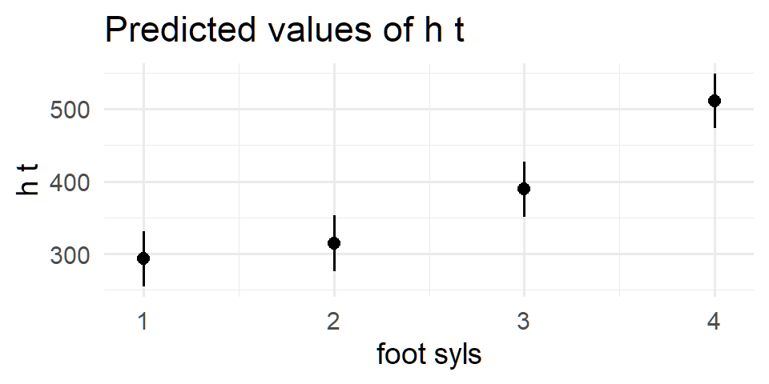

$pre_syls

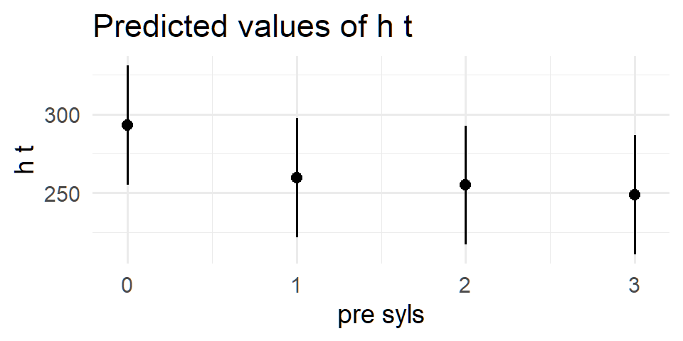

$fin_phon

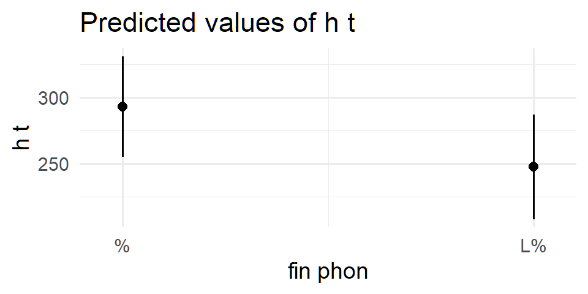

$nuc_new_word

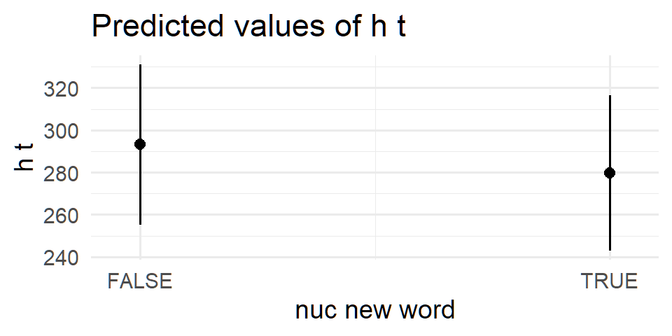

$gender

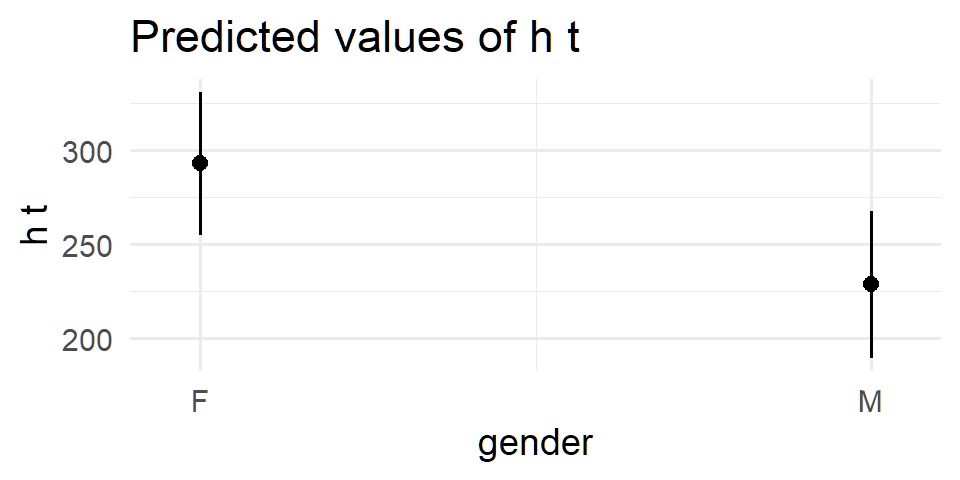

summary of model: h_t ~ foot_syls + pre_syls + fin_phon + nuc_new_word + gender + (1 | speaker) + (1 | str_syl)

| term | estimate | conf.low | conf.high | std.error | t.value | df | p.value |
| --- | --- | --- | --- | --- | --- | --- | --- |
| (Intercept) | 293.154 | 242.20439 | 344.103763 | 19.362 | 15.141 | 4.64 | 4.0e-05 |
| foot_syls2 | 21.253 | 11.75334 | 30.752549 | 4.839 | 4.392 | 766.11 | 1.3e-05 |
| foot_syls3 | 95.924 | 88.39586 | 103.451538 | 3.835 | 25.014 | 766.11 | 2.0e-101 |
| foot_syls4 | 217.839 | 205.86830 | 229.809793 | 6.098 | 35.723 | 767.73 | 2.1e-165 |
| pre_syls1 | -33.504 | -41.07084 | -25.937105 | 3.855 | -8.692 | 766.25 | 2.1e-17 |
| pre_syls2 | -38.186 | -50.18075 | -26.190252 | 6.110 | -6.249 | 767.95 | 6.8e-10 |
| pre_syls3 | -44.233 | -56.65214 | -31.814201 | 6.326 | -6.992 | 768.20 | 5.9e-12 |
| fin_phonL% | -45.707 | -57.40185 | -34.012689 | 5.957 | -7.672 | 769.45 | 5.1e-14 |
| nuc_new_wordTRUE | -13.416 | -20.73790 | -6.094325 | 3.730 | -3.597 | 767.49 | 3e-04 |
| genderM | -64.510 | -97.96942 | -31.051391 | 14.792 | -4.361 | 9.01 | 0.0018 |

b0 for h_t ~ foot_syls + pre_syls + fin_phon + nuc_new_word + gender + (1 | speaker) + (1 | str_syl)

| intercept | estimate | conf.low | conf.high | std.error | t.value | df | p.value |
| --- | --- | --- | --- | --- | --- | --- | --- |
| foot_syls1 | 293.5 | 242.5 | 344.4 | 19.398 | 15.129 | 4.68 | 3.8e-05 |
| foot_syls2 | 315.1 | 264.5 | 365.8 | 19.853 | 15.874 | 5.13 | 1.5e-05 |
| foot_syls3 | 390.4 | 339.5 | 441.3 | 19.395 | 20.130 | 4.67 | 1.0e-05 |
| foot_syls4 | 511.7 | 460.7 | 562.8 | 19.223 | 26.620 | 4.52 | 3.9e-06 |
| pre_syls0 | 293.5 | 242.5 | 344.4 | 19.398 | 15.129 | 4.68 | 3.8e-05 |
| pre_syls1 | 259.1 | 208.2 | 310 | 19.405 | 13.353 | 4.68 | 6.6e-05 |
| pre_syls2 | 254.4 | 203.5 | 305.3 | 19.387 | 13.124 | 4.67 | 7.3e-05 |
| pre_syls3 | 248.4 | 197.4 | 299.3 | 19.336 | 12.845 | 4.62 | 8.6e-05 |

b1 for h_t ~ foot_syls + pre_syls + fin_phon + nuc_new_word + gender + (1 | speaker) + (1 | str_syl)

| intercept | slope | estimate | conf.low | conf.high | std.error | t.value | df | p.value |
| --- | --- | --- | --- | --- | --- | --- | --- | --- |
| foot_syls1 | foot_syls2 | 21.7 | 12.1 | 31.3 | 4.878 | 4.445 | 767.11 | 1.0e-05 |
| foot_syls1 | foot_syls3 | 96.9 | 89.4 | 104.5 | 3.857 | 25.133 | 767.11 | 3.7e-102 |
| foot_syls1 | foot_syls4 | 218.3 | 206.2 | 230.3 | 6.148 | 35.503 | 768.74 | 3.4e-164 |
| foot_syls2 | foot_syls3 | 75.3 | 65.1 | 85.4 | 5.183 | 14.521 | 767.26 | 2.2e-42 |
| foot_syls2 | foot_syls4 | 196.6 | 184.2 | 209 | 6.334 | 31.039 | 768.66 | 9.5e-138 |
| foot_syls3 | foot_syls4 | 121.3 | 108.8 | 133.9 | 6.377 | 19.026 | 768.73 | 2.0e-66 |
| pre_syls0 | pre_syls1 | -34.4 | -42 | -26.7 | 3.880 | -8.853 | 767.24 | 5.8e-18 |
| pre_syls0 | pre_syls2 | -39 | -51.1 | -26.9 | 6.157 | -6.339 | 768.96 | 3.9e-10 |
| pre_syls0 | pre_syls3 | -45.1 | -57.6 | -32.6 | 6.375 | -7.073 | 769.19 | 3.4e-12 |
| pre_syls1 | pre_syls2 | -4.681 | -14.1 | 4.698 | 4.778 | -0.980 | 768.96 | 0.327 |
| pre_syls1 | pre_syls3 | -10.7 | -20.7 | -0.832 | 5.048 | -2.128 | 768.02 | 0.034 |
| pre_syls2 | pre_syls3 | -6.06 | -13.4 | 1.297 | 3.748 | -1.617 | 753.35 | 0.106 |
| intercept | fin_phonL% | -45.9 | -57.7 | -34.1 | 6.007 | -7.641 | 770.48 | 6.4e-14 |
| intercept | nuc_new_wordTRUE | -13.4 | -20.8 | -6.04 | 3.761 | -3.569 | 768.43 | 3.8e-04 |
| intercept | genderM | -64.3 | -97.9 | -30.6 | 14.859 | -4.324 | 9.01 | 0.002 |

### Analysis of H F0

step() suggests: `h_f0 ~ foot_syls + fin_phon + gender + (1 | speaker) + (1 | nuc_pre_text)` - but retaining all fixed effects, and only removing `(1 | foot_dur) + (1 | nuc_pre_text)`

- model needs trimming (residuals +/- 4 s.d.)

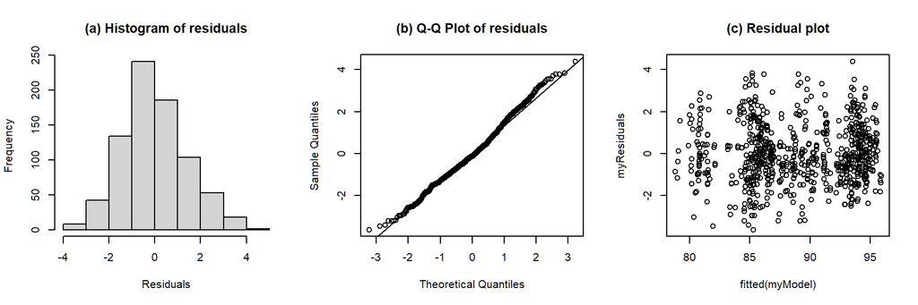

```
## Formula:  h_f0 ~ foot_syls + pre_syls + fin_phon + nuc_new_word + (1 | speaker) + (1 | speech_rate) + (1 | str_syl)
##
## Linear mixed model fit by REML. t-tests use Satterthwaite's method [
## lmerModLmerTest]
## Formula: h_f0_equation
##    Data: nuc_h_f0.trimmed
## Control:
## lmerControl(optimizer = optimizer, calc.derivs = FALSE, optCtrl = list(method = "nlminb",
##     starttests = FALSE, kkt = FALSE))
##
## REML criterion at convergence: 2948.1
##
## Scaled residuals:
##      Min       1Q   Median       3Q      Max
## -2.50753 -0.63537 -0.09025  0.60733  3.02640
##
## Random effects:
##  Groups      Name        Variance Std.Dev.
##  speech_rate (Intercept)  0.1518  0.3896
##  speaker     (Intercept) 21.0669  4.5899
##  str_syl     (Intercept)  0.4149  0.6442
##  Residual                 2.0992  1.4489
## Number of obs: 787, groups:  speech_rate, 635; speaker, 11; str_syl, 3
##
## Fixed effects:
##                  Estimate Std. Error       df t value Pr(>|t|)
## (Intercept)       87.0026     1.4753  12.4744  58.972  < 2e-16 ***
## foot_syls2         0.8507     0.2765 701.7554   3.076 0.002177 **
## foot_syls3         2.2959     0.2184 717.4503  10.511  < 2e-16 ***
## foot_syls4         2.0329     0.3460 745.9976   5.875 6.37e-09 ***
## pre_syls1          0.8092     0.2199 702.6286   3.680 0.000252 ***
## pre_syls2          0.7428     0.3481 667.0648   2.134 0.033201 *
## pre_syls3          1.1368     0.3597 642.6558   3.160 0.001650 **
## fin_phonL%        -0.6195     0.3386 766.4694  -1.830 0.067666 .
## nuc_new_wordTRUE   0.4628     0.2106 657.3719   2.198 0.028301 *
## ---
## Signif. codes:  0 '***' 0.001 '**' 0.01 '*' 0.05 '.' 0.1 ' ' 1
##
## Correlation of Fixed Effects:
##             (Intr) ft_sy2 ft_sy3 ft_sy4 pr_sy1 pr_sy2 pr_sy3 fn_pL%
```

[output cut: 21 more lines]

```
## Backward reduced fixed-effect table:
## Degrees of freedom method: Satterthwaite
##
##              Eliminated  Sum Sq Mean Sq NumDF  DenDF F value    Pr(>F)
## fin_phon              1   7.539   7.539     1 766.49  3.3507 0.0675637 .
## foot_syls             0 273.351  91.117     3 767.46 40.3744 < 2.2e-16 ***
## pre_syls              0  38.787  12.929     3 613.97  5.7290 0.0007187 ***
## nuc_new_word          0   9.515   9.515     1 672.86  4.2163 0.0404225 *
## ---
## Signif. codes:  0 '***' 0.001 '**' 0.01 '*' 0.05 '.' 0.1 ' ' 1
##
## Model found:
## h_f0 ~ foot_syls + pre_syls + nuc_new_word + (1 | speaker) + (1 | str_syl)
##
## isSingular(my_model, tol = 1e-05 ) --> FALSE
```

Anova of model: h_f0 ~ foot_syls + pre_syls + fin_phon + nuc_new_word + (1 | speaker) + (1 | speech_rate) + (1 | str_syl)

| term | sumsq | meansq | NumDF | DenDF | F value | p.value | signif. |
| --- | --- | --- | --- | --- | --- | --- | --- |
| foot_syls | 257.993 | 85.998 | 3 | 722.341 | 40.967 | 1.864337e-24 | p<0.001 |
| pre_syls | 36.137 | 12.046 | 3 | 558.854 | 5.738 | 7.167826e-04 | p<0.001 |
| fin_phon | 7.029 | 7.029 | 1 | 766.469 | 3.348 | 6.766558e-02 |  |
| nuc_new_word | 10.141 | 10.141 | 1 | 657.372 | 4.831 | 2.830096e-02 | p<0.05 |

Conditional and marginal R<sup>2</sup> of model

| R2_conditional | R2_marginal |
| --- | --- |
| 0.91 | 0.02 |

$foot_syls

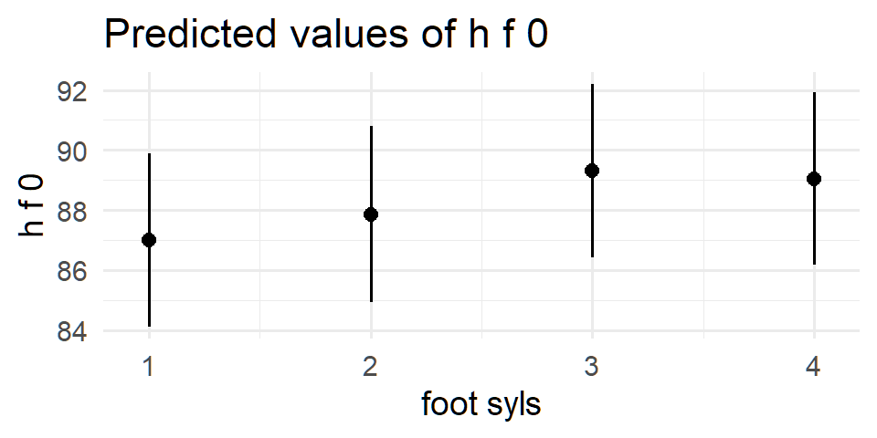

$pre_syls

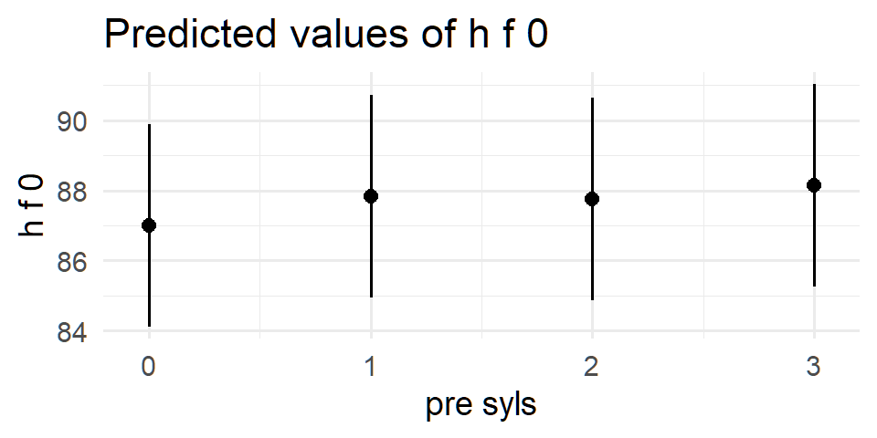

$fin_phon

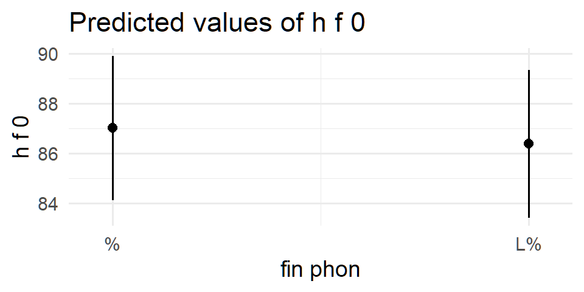

$nuc_new_word

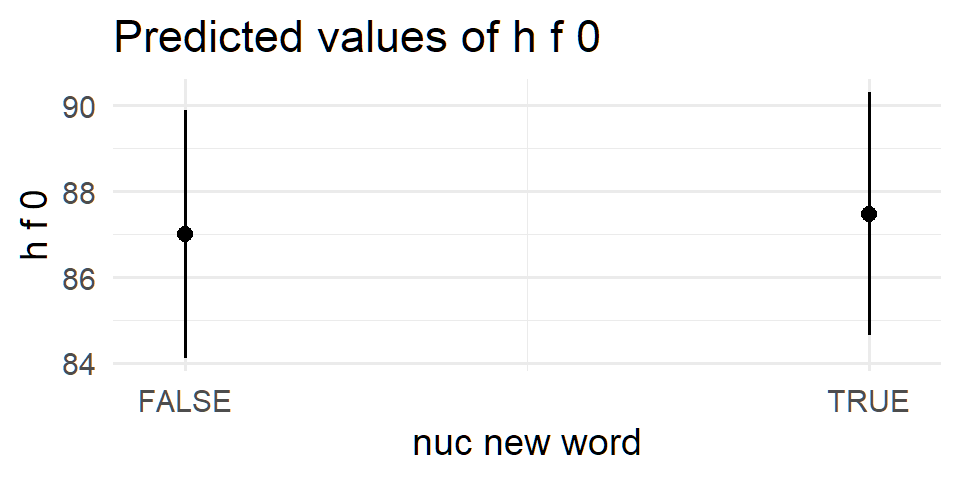

summary of model: h_f0 ~ foot_syls + pre_syls + fin_phon + nuc_new_word + (1 | speaker) + (1 | speech_rate) + (1 | str_syl)

| term | estimate | conf.low | conf.high | std.error | t.value | df | p.value |
| --- | --- | --- | --- | --- | --- | --- | --- |
| (Intercept) | 87.011 | 83.81293675 | 90.20911500 | 1.474 | 59.040 | 12.46 | 1.3e-16 |
| foot_syls2 | 0.849 | 0.30028575 | 1.39863750 | 0.280 | 3.037 | 702.42 | 0.0025 |
| foot_syls3 | 2.300 | 1.86658455 | 2.73404776 | 0.221 | 10.412 | 718.11 | 9.7e-24 |
| foot_syls4 | 2.034 | 1.34740115 | 2.72083353 | 0.350 | 5.815 | 744.84 | 9.0e-09 |
| pre_syls1 | 0.812 | 0.37533427 | 1.24882613 | 0.222 | 3.651 | 702.79 | 3e-04 |
| pre_syls2 | 0.748 | 0.05668984 | 1.43901014 | 0.352 | 2.125 | 664.12 | 0.034 |
| pre_syls3 | 1.138 | 0.42332426 | 1.85181191 | 0.364 | 3.128 | 636.63 | 0.0018 |
| fin_phonL% | -0.627 | -1.29846995 | 0.04523128 | 0.342 | -1.831 | 767.48 | 0.0675 |
| nuc_new_wordTRUE | 0.465 | 0.04722546 | 0.88279008 | 0.213 | 2.186 | 643.43 | 0.0292 |

b0 for h_f0 ~ foot_syls + pre_syls + fin_phon + nuc_new_word + (1 | speaker) + (1 | speech_rate) + (1 | str_syl)

| intercept | estimate | conf.low | conf.high | std.error | t.value | df | p.value |
| --- | --- | --- | --- | --- | --- | --- | --- |
| foot_syls1 | 87 | 83.8 | 90.2 | 1.474 | 59.040 | 12.46 | 1.3e-16 |
| foot_syls2 | 87.9 | 84.6 | 91.1 | 1.494 | 58.828 | 13.14 | 2.7e-17 |
| foot_syls3 | 89.3 | 86.1 | 92.5 | 1.474 | 60.607 | 12.45 | 9.2e-17 |
| foot_syls4 | 89 | 85.9 | 92.2 | 1.467 | 60.699 | 12.24 | 1.5e-16 |
| pre_syls0 | 87 | 83.8 | 90.2 | 1.474 | 59.040 | 12.46 | 1.3e-16 |
| pre_syls1 | 87.8 | 84.6 | 91 | 1.474 | 59.571 | 12.47 | 1.1e-16 |
| pre_syls2 | 87.8 | 84.6 | 91 | 1.474 | 59.527 | 12.48 | 1.1e-16 |
| pre_syls3 | 88.1 | 85 | 91.3 | 1.473 | 59.858 | 12.43 | 1.1e-16 |

b1 for h_f0 ~ foot_syls + pre_syls + fin_phon + nuc_new_word + (1 | speaker) + (1 | speech_rate) + (1 | str_syl)

| intercept | slope | estimate | conf.low | conf.high | std.error | t.value | df | p.value |
| --- | --- | --- | --- | --- | --- | --- | --- | --- |
| foot_syls1 | foot_syls2 | 0.849 | 0.3 | 1.399 | 0.280 | 3.037 | 702.42 | 0.002 |
| foot_syls1 | foot_syls3 | 2.3 | 1.867 | 2.734 | 0.221 | 10.412 | 718.11 | 9.7e-24 |
| foot_syls1 | foot_syls4 | 2.034 | 1.347 | 2.721 | 0.350 | 5.815 | 744.84 | 9.0e-09 |
| foot_syls2 | foot_syls3 | 1.451 | 0.867 | 2.035 | 0.297 | 4.878 | 694.81 | 1.3e-06 |
| foot_syls2 | foot_syls4 | 1.185 | 0.475 | 1.895 | 0.362 | 3.276 | 706.69 | 0.001 |
| foot_syls3 | foot_syls4 | -0.266 | -0.978 | 0.446 | 0.363 | -0.734 | 756.01 | 0.463 |
| pre_syls0 | pre_syls1 | 0.812 | 0.375 | 1.249 | 0.222 | 3.651 | 702.79 | 2.8e-04 |
| pre_syls0 | pre_syls2 | 0.748 | 0.057 | 1.439 | 0.352 | 2.125 | 664.12 | 0.034 |
| pre_syls0 | pre_syls3 | 1.138 | 0.423 | 1.852 | 0.364 | 3.128 | 636.63 | 0.002 |
| pre_syls1 | pre_syls2 | -0.064 | -0.6 | 0.472 | 0.273 | -0.235 | 600.75 | 0.814 |
| pre_syls1 | pre_syls3 | 0.325 | -0.238 | 0.889 | 0.287 | 1.134 | 569.70 | 0.257 |
| pre_syls2 | pre_syls3 | 0.39 | -0.022 | 0.801 | 0.209 | 1.862 | 354.71 | 0.063 |
| intercept | fin_phonL% | -0.627 | -1.298 | 0.045 | 0.342 | -1.831 | 767.48 | 0.068 |
| intercept | nuc_new_wordTRUE | 0.465 | 0.047 | 0.883 | 0.213 | 2.186 | 643.43 | 0.029 |

## E targets

### Analysis of E timing

- NB, E timing is not of interest!
- initial step() suggests:
- `e_t ~ foot_syls + pre_syls + fin_phon + nuc_new_word + gender + (1 | speaker) + (1 | str_syl) + (1 | foot_dur) + (1 | nuc_pre_text)`
- rerunning without `(1 | speech_rate)`, it suggests: `e_t ~ foot_syls + pre_syls + gender + (1 | speaker) + (1 | str_syl) + (1 | foot_dur)`
- However, model words, so retaining it.
- intercepts only model
- model needs trimming

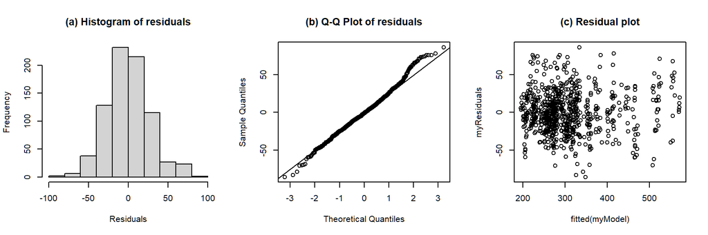

```
## Formula:  e_t ~ foot_syls + pre_syls + fin_phon + nuc_new_word + gender + (1 | speaker) + (1 | str_syl) + (1 | foot_dur) + (1 | nuc_pre_text)
##
## Linear mixed model fit by REML. t-tests use Satterthwaite's method [
## lmerModLmerTest]
## Formula: e_t_equation
##    Data: nuc_e_t.trimmed
## Control:
## lmerControl(optimizer = optimizer, calc.derivs = FALSE, optCtrl = list(method = "nlminb",
##     starttests = FALSE, kkt = FALSE))
##
## REML criterion at convergence: 7536.7
##
## Scaled residuals:
##      Min       1Q   Median       3Q      Max
## -3.02762 -0.61560 -0.03311  0.57471  3.05232
##
## Random effects:
##  Groups       Name        Variance Std.Dev.
##  foot_dur     (Intercept)   60.524  7.780
##  nuc_pre_text (Intercept)    1.496  1.223
##  speaker      (Intercept)  689.070 26.250
##  str_syl      (Intercept) 1005.336 31.707
##  Residual                  794.841 28.193
## Number of obs: 787, groups:
## foot_dur, 316; nuc_pre_text, 12; speaker, 11; str_syl, 3
##
## Fixed effects:
##                  Estimate Std. Error      df t value Pr(>|t|)
## (Intercept)       329.845     22.426   4.203  14.708 8.97e-05 ***
## foot_syls2         10.658      5.630   3.812   1.893   0.1348
## foot_syls3        117.285      4.281 734.396  27.397  < 2e-16 ***
## foot_syls4        248.725      7.082   4.236  35.120 2.20e-06 ***
## pre_syls1         -30.898      4.604   1.704  -6.711   0.0319 *
## pre_syls2         -30.058      7.145   2.826  -4.207   0.0276 *
## pre_syls3         -35.267      7.378   3.180  -4.780   0.0152 *
## fin_phonL%         -6.142      6.586 744.331  -0.933   0.3513
## nuc_new_wordTRUE   -5.885      4.277   5.065  -1.376   0.2266
## genderM           -47.763     16.033   8.993  -2.979   0.0155 *
## ---
## Signif. codes:  0 '***' 0.001 '**' 0.01 '*' 0.05 '.' 0.1 ' ' 1
```

[output cut: 27 more lines]

```
## Degrees of freedom method: Satterthwaite
##
##              Eliminated  Sum Sq Mean Sq NumDF  DenDF  F value    Pr(>F)
## fin_phon              1     728     728     1 768.87   0.9149   0.33912
## nuc_new_word          2    1698    1698     1 743.16   2.1392   0.14400
## foot_syls             0 2378140  792713     3 751.05 996.7828 < 2.2e-16 ***
## pre_syls              0   42948   14316     3 750.88  18.0016 2.734e-11 ***
## gender                0    7052    7052     1   8.99   8.8677   0.01552 *
## ---
## Signif. codes:  0 '***' 0.001 '**' 0.01 '*' 0.05 '.' 0.1 ' ' 1
##
## Model found:
## e_t ~ foot_syls + pre_syls + gender + (1 | speaker) + (1 | str_syl) + (1 | foot_dur)
##
## isSingular(my_model, tol = 1e-05 ) --> FALSE
```

Anova of model: e_t ~ foot_syls + pre_syls + fin_phon + nuc_new_word + gender + (1 | speaker) + (1 | str_syl) + (1 | foot_dur) + (1 | nuc_pre_text)

| term | sumsq | meansq | NumDF | DenDF | F value | p.value | signif. |
| --- | --- | --- | --- | --- | --- | --- | --- |
| foot_syls | 1485466.700 | 495155.567 | 3 | 6.437 | 622.962 | 2.632571e-08 | p<0.001 |
| pre_syls | 36936.390 | 12312.130 | 3 | 2.947 | 15.490 | 2.600820e-02 | p<0.05 |
| fin_phon | 691.385 | 691.385 | 1 | 744.331 | 0.870 | 3.513018e-01 |  |
| nuc_new_word | 1504.824 | 1504.824 | 1 | 5.065 | 1.893 | 2.265627e-01 |  |
| gender | 7053.962 | 7053.962 | 1 | 8.993 | 8.875 | 1.548716e-02 | p<0.05 |

Conditional and marginal R<sup>2</sup> of model

| R2_conditional | R2_marginal |
| --- | --- |
| 0.9 | 0.69 |

$foot_syls

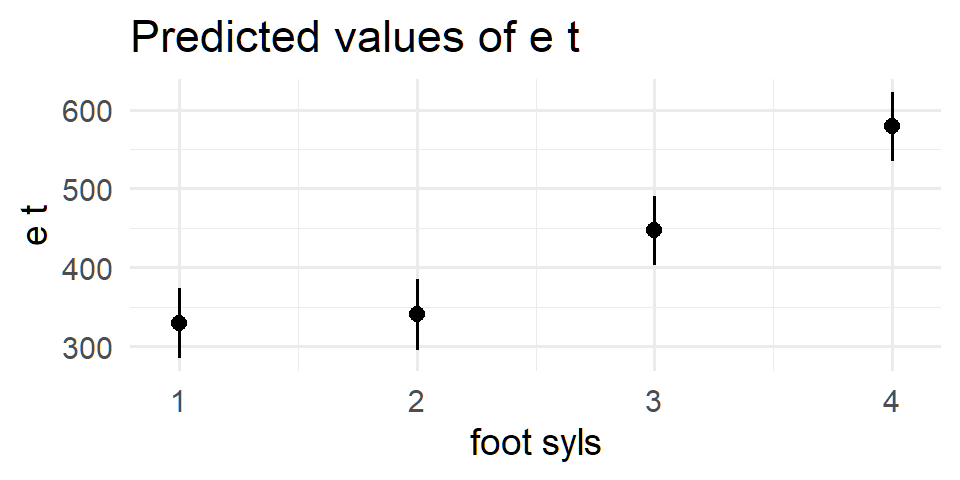

$pre_syls

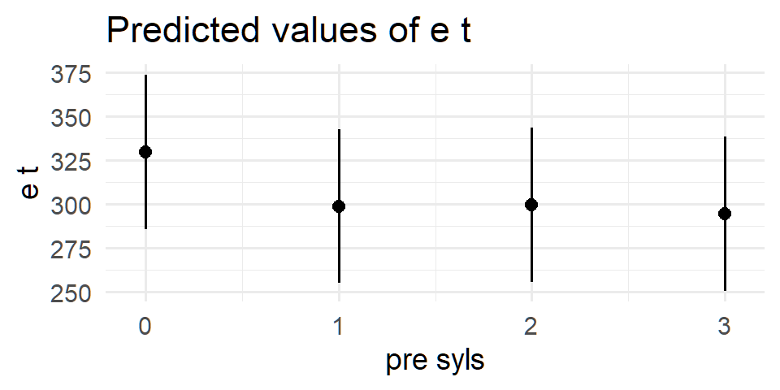

$fin_phon

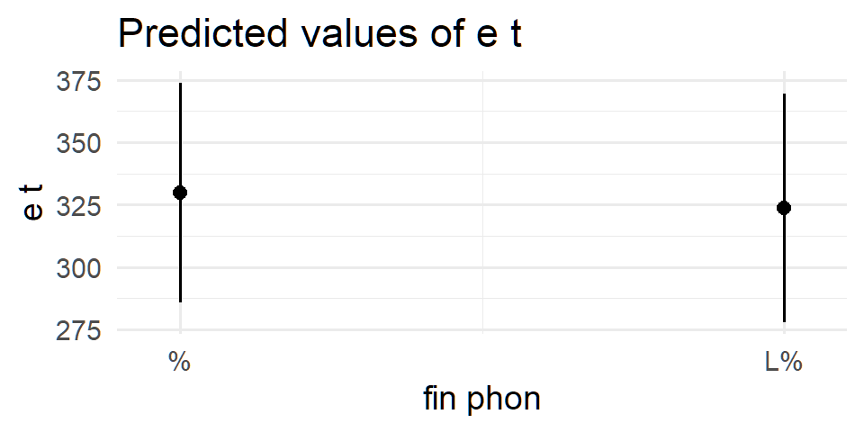

$nuc_new_word

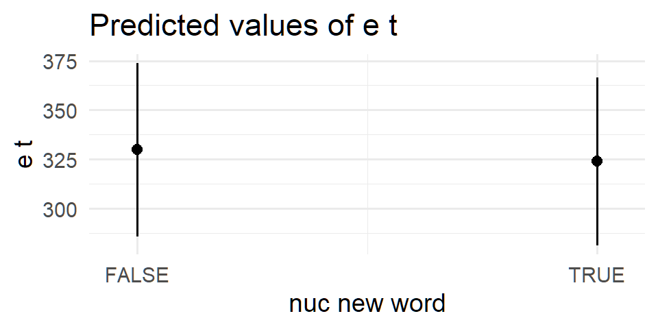

$gender

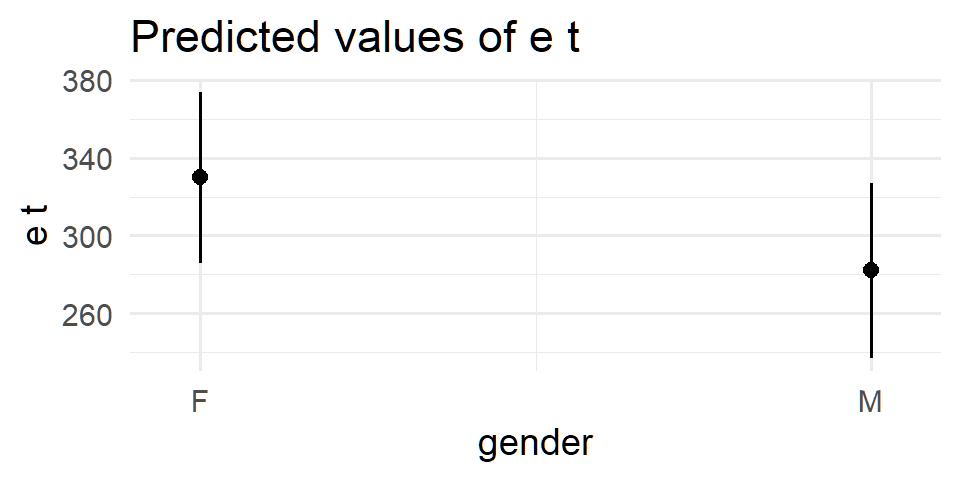

summary of model: e_t ~ foot_syls + pre_syls + fin_phon + nuc_new_word + gender + (1 | speaker) + (1 | str_syl) + (1 | foot_dur) + (1 | nuc_pre_text)

| term | estimate | conf.low | conf.high | std.error | t.value | df | p.value |
| --- | --- | --- | --- | --- | --- | --- | --- |
| (Intercept) | 329.845 | 268.751605 | 390.938911 | 22.426 | 14.708 | 4.20 | 9.0e-05 |
| foot_syls2 | 10.658 | -5.283727 | 26.599199 | 5.630 | 1.893 | 3.81 | 0.1348 |
| foot_syls3 | 117.285 | 108.880999 | 125.689778 | 4.281 | 27.397 | 734.40 | 2.1e-114 |
| foot_syls4 | 248.725 | 229.486073 | 267.964425 | 7.082 | 35.120 | 4.24 | 2.2e-06 |
| pre_syls1 | -30.898 | -54.393481 | -7.402906 | 4.604 | -6.711 | 1.70 | 0.0319 |
| pre_syls2 | -30.058 | -53.613039 | -6.502739 | 7.145 | -4.207 | 2.83 | 0.0276 |
| pre_syls3 | -35.267 | -58.012705 | -12.520886 | 7.378 | -4.780 | 3.18 | 0.0152 |
| fin_phonL% | -6.142 | -19.071454 | 6.786776 | 6.586 | -0.933 | 744.33 | 0.3513 |
| nuc_new_wordTRUE | -5.885 | -16.838069 | 5.067396 | 4.277 | -1.376 | 5.07 | 0.2266 |
| genderM | -47.763 | -84.036722 | -11.489367 | 16.033 | -2.979 | 8.99 | 0.0155 |

b0 for e_t ~ foot_syls + pre_syls + fin_phon + nuc_new_word + gender + (1 | speaker) + (1 | str_syl) + (1 | foot_dur) + (1 | nuc_pre_text)

| intercept | estimate | conf.low | conf.high | std.error | t.value | df | p.value |
| --- | --- | --- | --- | --- | --- | --- | --- |
| foot_syls1 | 329.8 | 268.8 | 390.9 | 22.426 | 14.708 | 4.20 | 9.0e-05 |
| foot_syls2 | 340.5 | 279.6 | 401.4 | 22.971 | 14.823 | 4.55 | 5.1e-05 |
| foot_syls3 | 447.1 | 386 | 508.2 | 22.419 | 19.945 | 4.20 | 2.6e-05 |
| foot_syls4 | 578.6 | 517.2 | 639.9 | 22.269 | 25.982 | 4.08 | 1.1e-05 |
| pre_syls0 | 329.8 | 268.8 | 390.9 | 22.426 | 14.708 | 4.20 | 9.0e-05 |
| pre_syls1 | 298.9 | 237.9 | 360 | 22.431 | 13.327 | 4.21 | 1.3e-04 |
| pre_syls2 | 299.8 | 238.7 | 360.9 | 22.418 | 13.372 | 4.20 | 1.3e-04 |
| pre_syls3 | 294.6 | 233.4 | 355.7 | 22.365 | 13.171 | 4.16 | 1.5e-04 |

b1 for e_t ~ foot_syls + pre_syls + fin_phon + nuc_new_word + gender + (1 | speaker) + (1 | str_syl) + (1 | foot_dur) + (1 | nuc_pre_text)

| intercept | slope | estimate | conf.low | conf.high | std.error | t.value | df | p.value |
| --- | --- | --- | --- | --- | --- | --- | --- | --- |
| foot_syls1 | foot_syls2 | 10.7 | -5.284 | 26.6 | 5.630 | 1.893 | 3.81 | 0.135 |
| foot_syls1 | foot_syls3 | 117.3 | 108.9 | 125.7 | 4.281 | 27.397 | 734.40 | 2.1e-114 |
| foot_syls1 | foot_syls4 | 248.7 | 229.5 | 268 | 7.082 | 35.120 | 4.24 | 2.2e-06 |
| foot_syls2 | foot_syls3 | 106.6 | 91.1 | 122.1 | 5.976 | 17.844 | 4.83 | 1.3e-05 |
| foot_syls2 | foot_syls4 | 238.1 | 219 | 257.1 | 7.268 | 32.755 | 4.70 | 1.0e-06 |
| foot_syls3 | foot_syls4 | 131.4 | 112.4 | 150.5 | 7.285 | 18.043 | 4.75 | 1.5e-05 |
| pre_syls0 | pre_syls1 | -30.9 | -54.4 | -7.403 | 4.604 | -6.711 | 1.70 | 0.032 |
| pre_syls0 | pre_syls2 | -30.1 | -53.6 | -6.503 | 7.145 | -4.207 | 2.83 | 0.028 |
| pre_syls0 | pre_syls3 | -35.3 | -58 | -12.5 | 7.378 | -4.780 | 3.18 | 0.015 |
| pre_syls1 | pre_syls2 | 0.84 | -13.8 | 15.4 | 5.450 | 0.154 | 4.41 | 0.884 |
| pre_syls1 | pre_syls3 | -4.369 | -18.9 | 10.1 | 5.728 | -0.763 | 5.27 | 0.478 |
| pre_syls2 | pre_syls3 | -5.209 | -16.1 | 5.7 | 4.266 | -1.221 | 5.09 | 0.276 |
| intercept | fin_phonL% | -6.142 | -19.1 | 6.787 | 6.586 | -0.933 | 744.33 | 0.351 |
| intercept | nuc_new_wordTRUE | -5.885 | -16.8 | 5.067 | 4.277 | -1.376 | 5.07 | 0.227 |
| intercept | genderM | -47.8 | -84 | -11.5 | 16.033 | -2.979 | 8.99 | 0.015 |